# startR 2: Opérateurs et fonctions

Lise Vaudor

21 mars 2017

# Opérateurs arithmétiques

Ils permettent d’effectuer des opérations arithmétiques simples, comme des additions, des multiplications,etc.

```r
v1
```

```
## [1]  2.3  3.6  1.1  2.4  2.5 10.2  5.1  2.0
```

```r
v1+4 # addition
```

```
## [1]  6.3  7.6  5.1  6.4  6.5 14.2  9.1  6.0
```

```r
v1-3 # soustraction
```

```
## [1] -0.7  0.6 -1.9 -0.6 -0.5  7.2  2.1 -1.0
```

```r
v1*5 # multiplication
```

```
## [1] 11.5 18.0  5.5 12.0 12.5 51.0 25.5 10.0
```

```r
v1/4 # division
```

```
## [1] 0.575 0.900 0.275 0.600 0.625 2.550 1.275 0.500
```

```r
v1^2 # puissance
```

```
## [1]   5.29  12.96   1.21   5.76   6.25 104.04  26.01   4.00
```

# Opérateurs de comparaison

Ils permettent de **comparer** des vecteurs entre eux.

```r
v1
```

```
## [1]  2.3  3.6  1.1  2.4  2.5 10.2  5.1  2.0
```

```r
v1==3.6 # égal à
```

```
## [1] FALSE  TRUE FALSE FALSE FALSE FALSE FALSE FALSE
```

```r
v1!=2   # différent de
```

```
## [1]  TRUE  TRUE  TRUE  TRUE  TRUE  TRUE  TRUE FALSE
```

```r
v1
```

```
## [1]  2.3  3.6  1.1  2.4  2.5 10.2  5.1  2.0
```

```r
v1<4  # plus petit
```

```
## [1]  TRUE  TRUE  TRUE  TRUE  TRUE FALSE FALSE  TRUE
```

```r
v1>10 # plus grand
```

```
## [1] FALSE FALSE FALSE FALSE FALSE  TRUE FALSE FALSE
```

```r
v1<=5 # plus petit ou égal
```

```
## [1]  TRUE  TRUE  TRUE  TRUE  TRUE FALSE FALSE  TRUE
```

```r
v1>=3 # plus grand ou égal
```

```
## [1] FALSE  TRUE FALSE FALSE FALSE  TRUE  TRUE FALSE
```

# Opérateurs logiques

Ils permettent de **vérifier si une proposition est vraie** ou non.

```r
v1
```

```
## [1]  2.3  3.6  1.1  2.4  2.5 10.2  5.1  2.0
```

```r
!(v1>10)    # NON logique
```

```
## [1]  TRUE  TRUE  TRUE  TRUE  TRUE FALSE  TRUE  TRUE
```

```r
v1<2 & v1>5 # ET logique
```

```
## [1] FALSE FALSE FALSE FALSE FALSE FALSE FALSE FALSE
```

```r
v1<3 | v1>5 # OU logique
```

```
## [1]  TRUE FALSE  TRUE  TRUE  TRUE  TRUE  TRUE  TRUE
```

Notez également l’existence de la fonction **is.na()** qui permet d’évaluer si les éléments d’un vecteur sont vides ou non!

```r
v9 <- c(3.2, NA, 8.9, 42.3, 59.2, NA)
is.na(v9)
```

```
## [1] FALSE  TRUE FALSE FALSE FALSE  TRUE
```

# Opérateurs logiques ou de comparaison et fonction which()

L’utilisation d’opérateurs de comparaison et d’opérateurs logiques permet notamment de **rechercher certains éléments des objets ayant certaines caractéristiques**, grâce à la fonction `which()`.

Par exemple:

```r
v1
```

```
## [1]  2.3  3.6  1.1  2.4  2.5 10.2  5.1  2.0
```

```r
which(v1>3)
```

```
## [1] 2 6 7
```

```r
v1[which(v1>3)]
```

```
## [1]  3.6 10.2  5.1
```

```r
v2
```

```
## [1] "Paris"       "Lyon"        "Marseille"   "Rennes"      "Montpellier"
```

```r
which(v2=="Marseille")
```

```
## [1] 3
```

```r
v2[which(v2=="Marseille")]
```

```
## [1] "Marseille"
```

Notez bien la différence entre les **indices** et les **valeurs** des vecteurs: `which` renvoie des **indices**, c’est à dire des numéros d’éléments.

# Description des variables: Moyenne et médiane

On peut décrire le **mode** d’une variable via sa **moyenne** ou sa **médiane**.

```r
x
```

```
##  [1] 53.0 44.7 58.5 35.7 42.1 56.6 63.1 36.5 43.8 46.9 51.2 59.6 41.0 41.5
## [15] 25.3 52.8 55.8 31.0 55.7 26.7 54.2 42.0 51.7 47.5 46.9 33.7 38.5 65.7
## [29] 58.4 46.3 40.7 47.3 53.7 43.7 51.1 43.4 52.5 23.5 61.2 63.4 40.6 59.2
## [43] 59.4 37.0 54.5 58.5 40.6 60.5 43.1 52.9
```

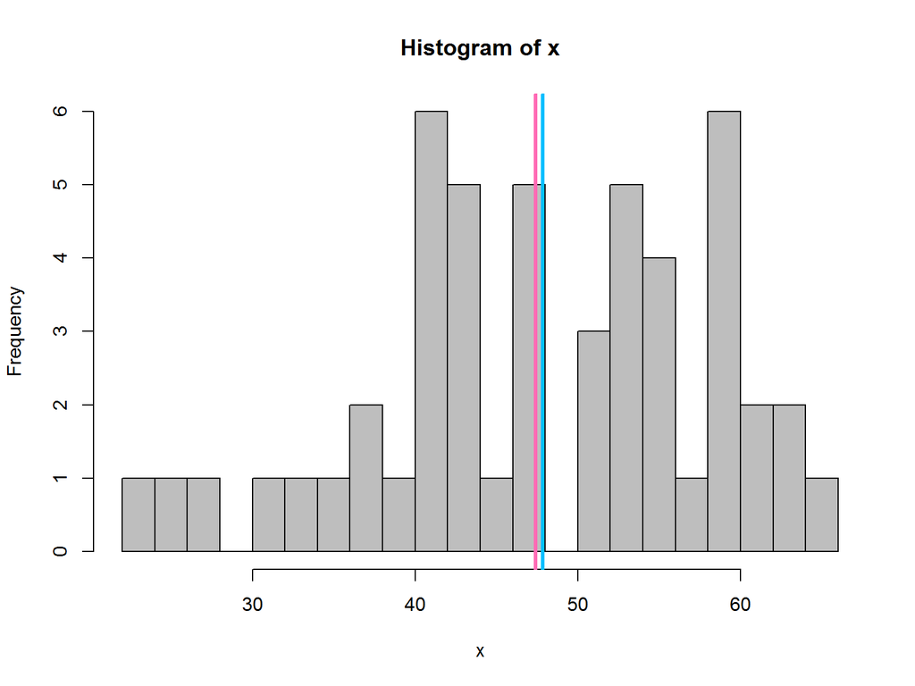

La **moyenne** d’une variable $x=(x_1,x_2,...,x_n)$ est égale à

$$\bar{x}=\frac{1}{n}\sum_{i=1}^{n}{x_i}$$

```r
mean(x)
```

```
## [1] 47.864
```

La **médiane** d’une variable $x=(x_1,x_2,...,x_n)$ est égale à la valeur $x_i$ telle qu’il y ait la moitié des observations au-dessus de $x_i$, et la moitié en dessous.

```r
median(x)
```

```
## [1] 47.4
```

La **distinction entre moyenne et médiane** peut être importante quand la variable a une distribution **asymétrique**.

# Description des variables: Variance et écart-type

On peut décrire la **variabilité** des données à travers la **variance** ou l’**écart-type**:

La variance et l’écart type de $x=(x_1,x_2,...,x_n)$ sont égales à
$$var(x)=\frac{1}{n-1}\sum_{i=1}^{n}{(x_i-\bar{x})^2}$$
$$sd(x)=\sqrt{var(x)}$$

$\sum{(x_i-\bar{x})^2}$ est la somme des écarts au carré entre les observations et la moyenne. Autrement dit, la variance est, à peu de choses près,la **moyenne des [[écarts à la moyenne] au carré]**.

Dans R, on calcule variance et écart-type à l’aide des fonctions `var()` et `sd()`

```r
var(x)
```

```
## [1] 106.9464
```

```r
sd(x)
```

```
## [1] 10.34149
```

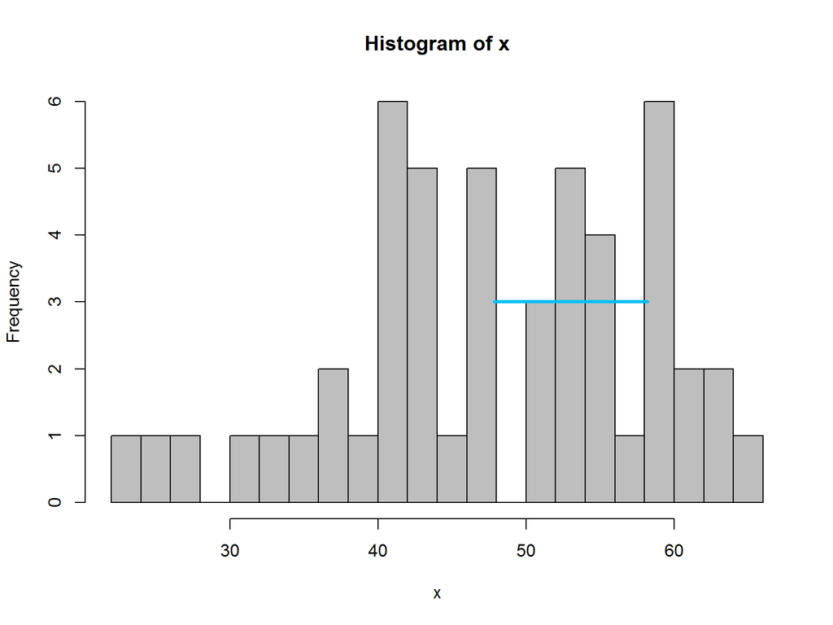

# Description des variables: Quantiles, minimum, maximum

Le **quantile d’ordre p** de $x=(x_1,x_2,...,x_n)$ correspond à la valeur $\lambda$ telle que p% des données sont inférieures à p.

$$\begin{eqnarray}
pr(X \leq \lambda)=p
\end{eqnarray}$$

Les quantiles d’ordre 25%, 50%, et 75% sont aussi appelés **premier quartile**, **deuxième quartile** (ou **médiane**), et **troisième** quartile.

```r
quantile(x, 0.10)
```

```
##  10%
## 35.5
```

Le quantile d’ordre 10% (ou 0.10) de x est 35.5.

Cela signifie que seulement 10% des valeurs de x sont inférieures à 35.5.

Par ailleurs, le **minimum** et **maximum** des variables peuvent être affichés comme suit:

```r
min(x)
```

```
## [1] 23.5
```

```r
max(x)
```

```
## [1] 65.7
```

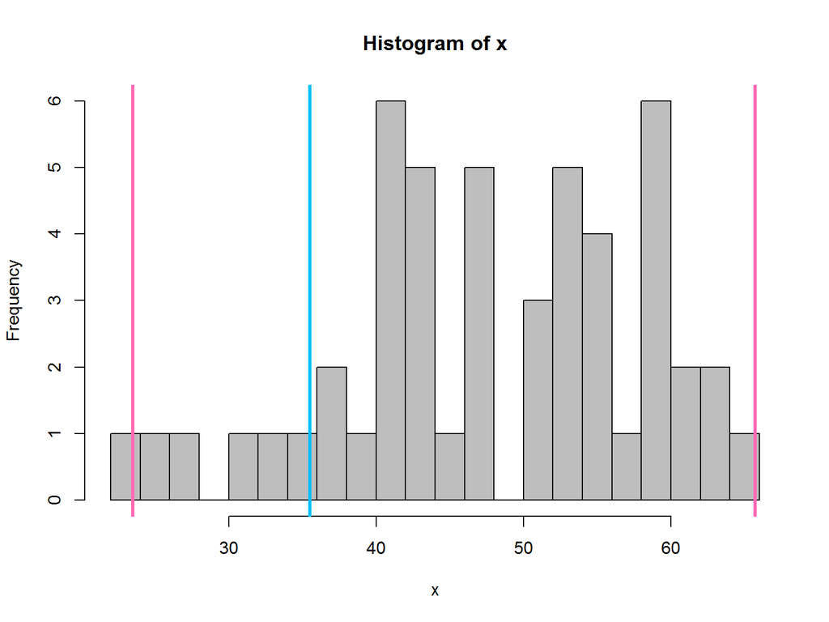

# Fonctions : Quelques remarques

Nous avons d’ores et déjà utilisé un certain nombre de fonctions, comme

- **c()**,
- **seq()**,
- **rep()**,
- **matrix()**,
- **mean()**, etc.

Toutes les fonctions que nous avons utilisées jusqu’à présent sont définies sur le **package de base** de R.

Les fonctions sont des **objets** qui ont toutes un **point commun**: elles s’écrivent avec des **parenthèses**, dans lesquelles l’utilisateur précise la **valeur des arguments** si besoin est.

Les arguments peuvent être **obligatoires** (la fonction ne peut pas fonctionner si ces arguments ne sont pas fournis par l’utilisateur) ou au contraire **optionnels**. Par exemple, dans

```r
quantile(x=x, probs=0.1)
```

```
##  10%
## 35.5
```

l’argument `x` est obligatoire, et l’argument `probs` est optionnel. On peut ainsi ne passer que l’argument `x` à la fonction:

```r
quantile(x=x)
```

```
##     0%    25%    50%    75%   100%
## 23.500 41.125 47.400 55.775 65.700
```

# Fonctions: Quelques remarques

Si l’on passe les arguments à la fonction **dans le bon ordre**, on n’a pas besoin de préciser le nom des arguments. Ainsi, il est possible d’appeler la fonction `quantile` des deux manières suivantes:

```r
quantile(x=x, probs=0.1)
```

```
##  10%
## 35.5
```

```r
quantile(x,0.1)
```

```
##  10%
## 35.5
```

En revanche, l’appel suivant produira une erreur:

```r
quantile(0.1,x)
```

```
## Error in quantile.default(0.1, x): 'probs' outside [0,1]
```

Pour accéder aux **informations** quant aux **arguments** d’une fonction, on peut consulter l’aide associée des deux façons suivantes:

```r
help(quantile)
?quantile
```

[figure not shown]

# Fonctions: Aide

Le fichier d’aide associé à une fonction est toujours structuré de la même manière. Sans trop détailler, voici les parties qui me semblent les plus importantes…

- **Description** qui décrit succintement le but de la fonction
- **Arguments** qui détaille les arguments, vous montre l’ordre dans lequel ils sont attendus, et vous précise leur effet ainsi que leurs valeurs par défaut (le cas échéant).
- une partie **Exemples** qui permet généralement de tester la fonction pour comprendre rapidement son usage.

**Détails** et **References** permettent en outre d’expliquer les détails de la méthode et éventuellement de citer la ou les publications associées à la méthode/fonction ou package.

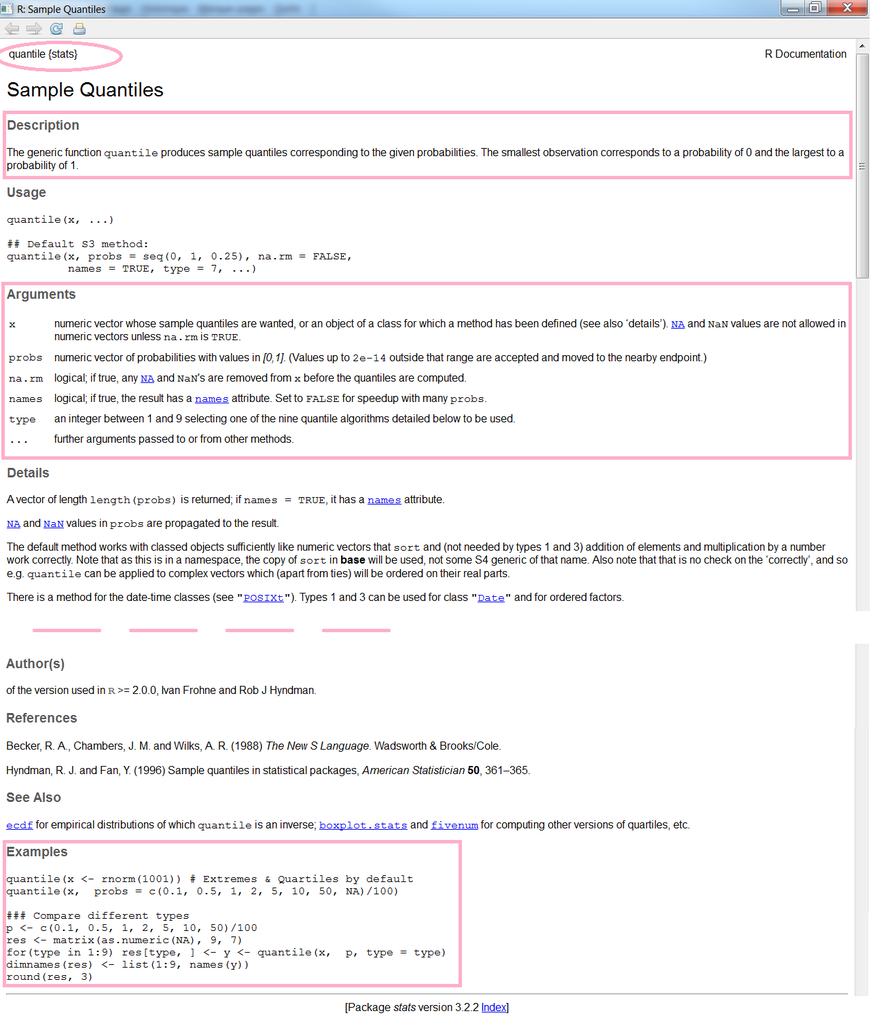

# Packages

Les packages sont des **paquets de fonctions** visant à réaliser des tâches un peu particulières. L’installation de base de R vous installe, par défaut, un certain nombre de packages (`base`, `methods`, `stats`, `graphics`, etc.)

Dans la suite de ce cours, nous serons amenés à utiliser le package **dplyr** qui sert à manipuler des tableaux de données.

Pour être en mesure d’utiliser les fonctions de ce package, il faut:

- **Installer le package**: les fonctions du package sont alors téléchargées depuis un serveur distant et enregistrées sur le disque dur de votre ordinateur:

```r
install.packages("dplyr")
```

- **Charger le package** (les fonctions du package sont chargées dans l’environnement R pour la session en cours)

```r
library(dplyr)
```

Vous pouvez également installer et charger les packages en passant par RStudio:

[figure not shown]